# Module 138

#### Contrast SVE:

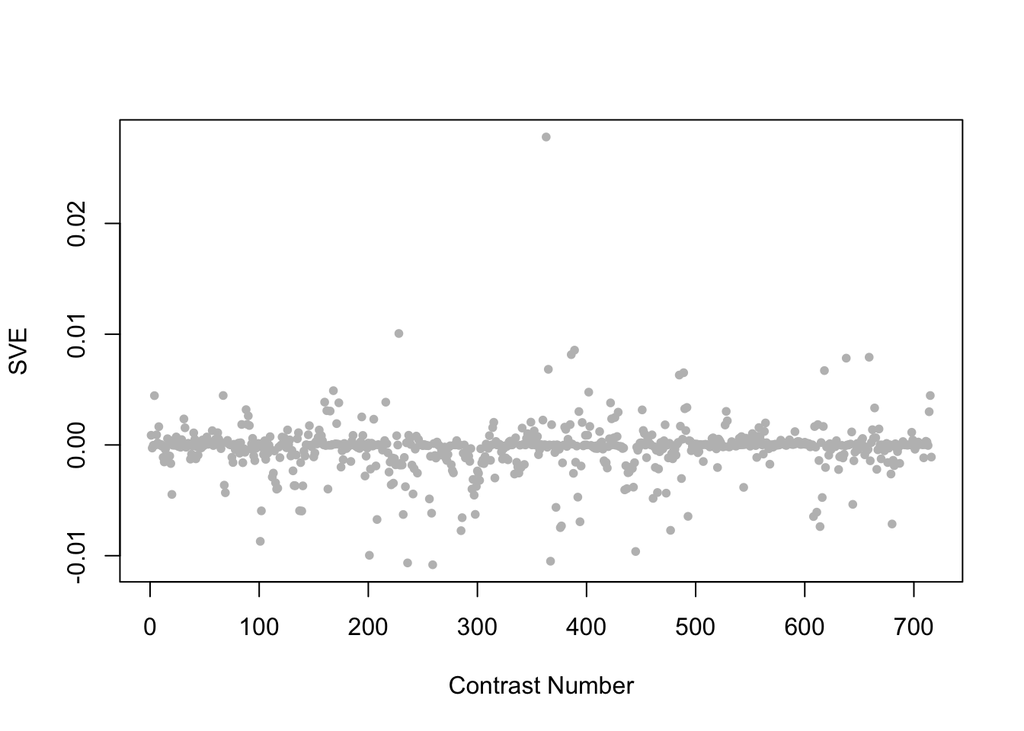

Positive SVE Contrasts:

|  | Contrast.Num | SVE | GEO.GSE | Cond.1 | Cond.2 | Mutation |
| --- | --- | --- | --- | --- | --- | --- |
| GSE36358.s2t1.vs.s0t1 | 363 | 0.03 | GSE36358 | Clino Rotation | Ground Control (Tsukuba space center) |  |
| GSE42592B.s2t2.vs.s0t2 | 228 | 0.01 | GSE42592 | cadmium_mid_expose-4h_rep1 | cadmium_control_expose-4h_rep1 |  |
| GSE32942.s2t1.vs.s1t1 | 389 | 0.01 | GSE32942 | WS5041 (mir 58(n4640); alg 1(tm492); opIs205). Replicate 1 | WS4303 (alg 1(tm492); opIs205). Replicate 1 | mir-58 |
| GSE34026.s2t1.vs.s0t1 | 386 | 0.01 | GSE34026 | N2 exposed to E7946, biological rep1 | N2 exposed to OP50(E.coli), biological rep1 |  |
| GSE15762.s1t1.vs.s0t1 | 659 | 0.01 | GSE15762 | hlh-30(tm1978)-1 | N2-1 | hlh-30 |

Negative SVE Contrasts:

|  | Contrast.Num | SVE | GEO.GSE | Cond.1 | Cond.2 | Mutation |
| --- | --- | --- | --- | --- | --- | --- |
| GSE41366A.s1t3.vs.s0t3 | 259 | -0.01 | GSE41366 | low_DDVP-2h_expose-20h_harvest-rep1 | control-2h_expose-20h_harvest-rep1 |  |
| GSE42592B.s2t3.vs.s2t2 | 236 | -0.01 | GSE42592 | cadmium_mid_expose-8h_rep1 | cadmium_mid_expose-4h_rep1 |  |
| GSE35360A.s1t1.vs.s0t1 | 367 | -0.01 | GSE35360 | HF 11d_0.2_rep1 | HF 11d control_rep1 |  |
| GSE43959.s3t2.vs.s3t1 | 201 | -0.01 | GSE43959 | N2 gravid adult on Comamonas DA1877 rep 1 | N2 young adult on Comamonas DA1877 rep 1 |  |
| GSE27677B.s0t9.vs.s0t7 | 445 | -0.01 | GSE27677 | N2, Fed 48 h, rep 1 | N2, Fed 24 h, rep 1 |  |

$~$

#### Contrast SVE, Up-Regulated Genes Only:

Calculating SVE for up-regulated and down-regulated genes separately may be more informative in many cases than projecting the up- and down- gene sets together. This is due to the fact that the weight distribution of many modules is highly skewed, indicating that only one of the hemi-modules may be biologically meaningful (i.e., a set of genes are strongly correlated by only a few genes (or none) are strongly anti-correlated to that set.)

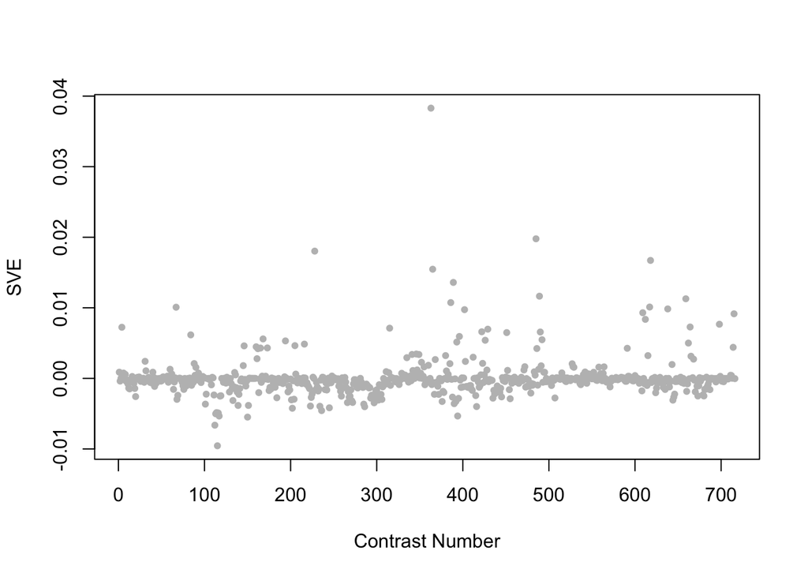

Positive SVE Contrasts:

|  | Contrast.Num | SVE | GEO.GSE | Cond.1 | Cond.2 | Mutation |
| --- | --- | --- | --- | --- | --- | --- |
| GSE36358.s2t1.vs.s0t1 | 363 | 0.04 | GSE36358 | Clino Rotation | Ground Control (Tsukuba space center) |  |
| GSE23528A.s0t5.vs.s0t1 | 485 | 0.02 | GSE23528 | Adult at T18, non-entrained control time-series experiment 4 | Adult at T2, non-entrained control time-series experiment 4 |  |
| GSE42592B.s2t2.vs.s0t2 | 228 | 0.02 | GSE42592 | cadmium_mid_expose-4h_rep1 | cadmium_control_expose-4h_rep1 |  |
| GSE21591.s1t1.vs.s2t1 | 618 | 0.02 | GSE21591 | N2_aFLAG_1 | Input_1 |  |
| GSE36358.s3t1.vs.s0t1 | 365 | 0.02 | GSE36358 | Hyper Gravity | Ground Control (Tsukuba space center) |  |

Negative SVE Contrasts:

|  | Contrast.Num | SVE | GEO.GSE | Cond.1 | Cond.2 | Mutation |
| --- | --- | --- | --- | --- | --- | --- |
| GSE54024.s1t1.vs.s5t1 | 115 | -0.01 | GSE54024 | Wild type young adults, biological rep 1 | ced-4(n1162) young adults, biological rep 1 | ced-4 |
| GSE54024.s4t1.vs.s5t1 | 112 | -0.01 | GSE54024 | isp-1(qm150) young adults, biological rep 1 | ced-4(n1162) young adults, biological rep 1 |  |
| GSE47778.s2t1.vs.s3t1 | 150 | -0.01 | GSE47778 | daf-2; replicate 1 | daf-16; replicate 1 | daf-2 vs. daf-16 |
| GSE54024.s3t1.vs.s6t1 | 117 | -0.01 | GSE54024 | nuo-6(qm200) young adults, biological rep 1 | isp-1(qm150) ced-4(n1162) double mutant young adults, biological rep 1 |  |
| GSE32339.s1t2.vs.s1t1 | 394 | -0.01 | GSE32339 | Adult Mutant, biological rep1 | Larval Mutant, biological rep1 |  |

$~$

#### Contrast SVE, Down-Regulated Genes Only:

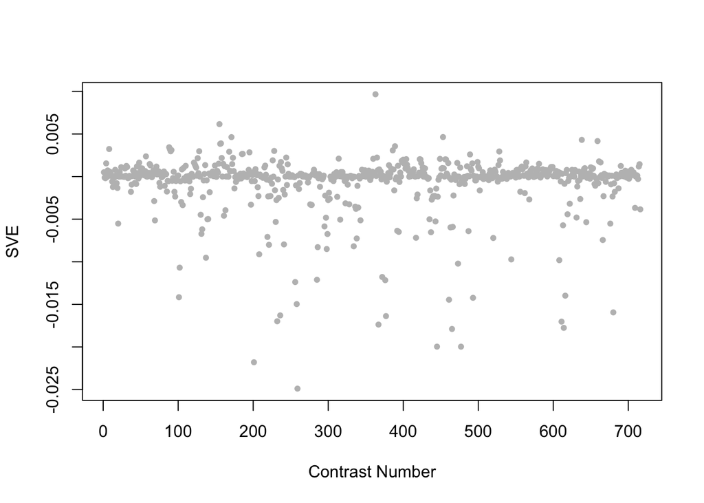

Positive SVE Contrasts:

|  | Contrast.Num | SVE | GEO.GSE | Cond.1 | Cond.2 | Mutation |
| --- | --- | --- | --- | --- | --- | --- |
| GSE36358.s2t1.vs.s0t1 | 363 | 0.01 | GSE36358 | Clino Rotation | Ground Control (Tsukuba space center) |  |
| GSE47778.s1t1.vs.s2t1 | 155 | 0.01 | GSE47778 | N2; replicate 1 | daf-2; replicate 1 | daf-2 |
| GSE25513.s3t1.vs.s0t1 | 453 | 0.00 | GSE25513 | aak-2 o/e (1) | WT (1) | aak-2 |
| GSE47778.s1t3.vs.s2t3 | 171 | 0.00 | GSE47778 | N2; UV; replicate 1 | daf-2; UV; replicate 1 | daf-2 |
| GSE18132.s2t1.vs.s0t1 | 638 | 0.00 | GSE18132 | Oga starved L1, biological replicate 1 | WT Starved L1, biological rep1 | oga-1 |

Negative SVE Contrasts:

|  | Contrast.Num | SVE | GEO.GSE | Cond.1 | Cond.2 | Mutation |
| --- | --- | --- | --- | --- | --- | --- |
| GSE41366A.s1t3.vs.s0t3 | 259 | -0.02 | GSE41366 | low_DDVP-2h_expose-20h_harvest-rep1 | control-2h_expose-20h_harvest-rep1 |  |
| GSE43959.s3t2.vs.s3t1 | 201 | -0.02 | GSE43959 | N2 gravid adult on Comamonas DA1877 rep 1 | N2 young adult on Comamonas DA1877 rep 1 |  |
| GSE23528A.s1t2.vs.s1t1 | 477 | -0.02 | GSE23528 | Adult at T6 in LD, time-series experiment 3 | Adult at T2 in LD, time-series experiment 3 |  |
| GSE27677B.s0t9.vs.s0t7 | 445 | -0.02 | GSE27677 | N2, Fed 48 h, rep 1 | N2, Fed 24 h, rep 1 |  |
| GSE23528A.s1t5.vs.s0t5 | 465 | -0.02 | GSE23528 | Adult at T18 in LD, time-series experiment 3 | Adult at T18, non-entrained control time-series experiment 4 |  |

$~$

$~$

#### GO Term Enrichment:

This analysis tests each hemi-module for enrichment of specific GO terms. Only gene-level annotations (e.g., as would be found on the gene’s page in Wormbase) are tested - the hierarchical structure of the GO ontology is not taken into account.

*Note: At least the top two most enriched terms from each GO domain (BP/MF/CC) are shown, even when not statistically significant.*

##### Enriched GO terms: Hemi-module A

| ID | GO.Term | GO Domain | Raw p-value | Adj p-value |
| --- | --- | --- | --- | --- |
| [GO_0006355](http://amigo.geneontology.org/amigo/term/GO:0006355) | regulation of transcription, DNA-templated | BP | 4.77e-03 | 9.94e-01 |
| [GO_0006515](http://amigo.geneontology.org/amigo/term/GO:0006515) | protein quality control for misfolded or incompletely synthesized proteins | BP | 5.73e-03 | 9.94e-01 |
| [GO_0000224](http://amigo.geneontology.org/amigo/term/GO:0000224) | peptide-N4-(N-acetyl-beta-glucosaminyl)asparagine amidase activity | MF | 3.37e-03 | 9.97e-01 |
| [GO_0003700](http://amigo.geneontology.org/amigo/term/GO:0003700) | DNA-binding transcription factor activity | MF | 5.74e-03 | 9.97e-01 |
| [GO_0098894](http://amigo.geneontology.org/amigo/term/GO:0098894) | extrinsic component of presynaptic endocytic zone membrane | CC | 8.89e-03 | 9.95e-01 |
| [GO_0045211](http://amigo.geneontology.org/amigo/term/GO:0045211) | postsynaptic membrane | CC | 1.10e-02 | 9.95e-01 |

##### Enriched GO terms: Hemi-module B

| ID | GO.Term | GO Domain | Raw p-value | Adj p-value |
| --- | --- | --- | --- | --- |
| [GO_0032237](http://amigo.geneontology.org/amigo/term/GO:0032237) | activation of store-operated calcium channel activity | BP | 1.50e-03 | 1.00e+00 |
| [GO_1901341](http://amigo.geneontology.org/amigo/term/GO:1901341) | positive regulation of store-operated calcium channel activity | BP | 1.50e-03 | 1.00e+00 |
| [GO_0005483](http://amigo.geneontology.org/amigo/term/GO:0005483) | soluble NSF attachment protein activity | MF | 2.99e-03 | 1.00e+00 |
| [GO_0030215](http://amigo.geneontology.org/amigo/term/GO:0030215) | semaphorin receptor binding | MF | 5.97e-03 | 1.00e+00 |
| [GO_1902554](http://amigo.geneontology.org/amigo/term/GO:1902554) | serine/threonine protein kinase complex | CC | 4.48e-03 | 1.00e+00 |
| [GO_0005774](http://amigo.geneontology.org/amigo/term/GO:0005774) | vacuolar membrane | CC | 1.49e-02 | 1.00e+00 |

$~$

$~$

#### Tissue Enrichment:

This analysis tests each hemi-module for enrichment of genes associated with anatomy terms. Negative enrichment scores indicate fewer hemi-module genes than expected by random chance were associated with the anatomy term in question.

##### Enriched tissues: Hemi-module A

No significant annotations.

##### Enriched tissues: Hemi-module B

No significant annotations.

$~$

$~$

#### HOMER promoter motif enrichment:

This analysis tests each hemi-module for enrichment of 108 known *C. elegans* transcription factor binding site motifs (see [108 CE motifs](https://katiepod.github.io//all.worm.motifs.html)) using the HOMER (Hypergeometric Optimization of Motif EnRichment) software (see [PMID:20513432](https://pubmed.ncbi.nlm.nih.gov/20513432)). HOMER was run using default parameters on sequences 1 kb upstream of the transcription start site.

##### Motif enrichment: Hemi-module A

Total target sequences = 160  
Total background sequences = 40481  
* - possible false positive

Rank

Motif

P-value

log P-pvalue

% of Targets

% of Background

STD(Bg STD)

Best Match/Details

Motif File

1 *

[figure not shown]

1e-10

-2.354e+01

6.25%

0.28%

283.9bp (265.9bp)

MF0010.1_Homeobox_class/Jaspar(0.617)  
[More Information](https://katiepod.github.io/HomerResults/m138_a_hemi_genes.txt.out.1kb/homerResults/motif1.info.html) | [Similar Motifs Found](https://katiepod.github.io/HomerResults/m138_a_hemi_genes.txt.out.1kb/homerResults/motif1.similar.html)

[motif file (matrix)](https://katiepod.github.io/HomerResults/m138_a_hemi_genes.txt.out.1kb/homerResults/motif1.motif)

2 *

[figure not shown]

1e-9

-2.288e+01

10.62%

1.35%

290.2bp (287.6bp)

atf-7/MA1438.1/Jaspar(0.675)  
[More Information](https://katiepod.github.io/HomerResults/m138_a_hemi_genes.txt.out.1kb/homerResults/motif2.info.html) | [Similar Motifs Found](https://katiepod.github.io/HomerResults/m138_a_hemi_genes.txt.out.1kb/homerResults/motif2.similar.html)

[motif file (matrix)](https://katiepod.github.io/HomerResults/m138_a_hemi_genes.txt.out.1kb/homerResults/motif2.motif)

3 *

[figure not shown]

1e-9

-2.273e+01

5.62%

0.21%

252.8bp (322.2bp)

ceh-38/MA1699.1/Jaspar(0.515)  
[More Information](https://katiepod.github.io/HomerResults/m138_a_hemi_genes.txt.out.1kb/homerResults/motif3.info.html) | [Similar Motifs Found](https://katiepod.github.io/HomerResults/m138_a_hemi_genes.txt.out.1kb/homerResults/motif3.similar.html)

[motif file (matrix)](https://katiepod.github.io/HomerResults/m138_a_hemi_genes.txt.out.1kb/homerResults/motif3.motif)

4 *

[figure not shown]

1e-9

-2.263e+01

4.38%

0.08%

301.4bp (272.7bp)

sma-4/MA0925.1/Jaspar(0.507)  
[More Information](https://katiepod.github.io/HomerResults/m138_a_hemi_genes.txt.out.1kb/homerResults/motif4.info.html) | [Similar Motifs Found](https://katiepod.github.io/HomerResults/m138_a_hemi_genes.txt.out.1kb/homerResults/motif4.similar.html)

[motif file (matrix)](https://katiepod.github.io/HomerResults/m138_a_hemi_genes.txt.out.1kb/homerResults/motif4.motif)

5 *

[figure not shown]

1e-9

-2.188e+01

8.12%

0.73%

239.1bp (291.0bp)

sma-4/MA0925.1/Jaspar(0.581)  
[More Information](https://katiepod.github.io/HomerResults/m138_a_hemi_genes.txt.out.1kb/homerResults/motif5.info.html) | [Similar Motifs Found](https://katiepod.github.io/HomerResults/m138_a_hemi_genes.txt.out.1kb/homerResults/motif5.similar.html)

[motif file (matrix)](https://katiepod.github.io/HomerResults/m138_a_hemi_genes.txt.out.1kb/homerResults/motif5.motif)

6 *

[figure not shown]

1e-9

-2.162e+01

3.12%

0.02%

185.5bp (202.9bp)

sma-4/MA0925.1/Jaspar(0.500)  
[More Information](https://katiepod.github.io/HomerResults/m138_a_hemi_genes.txt.out.1kb/homerResults/motif6.info.html) | [Similar Motifs Found](https://katiepod.github.io/HomerResults/m138_a_hemi_genes.txt.out.1kb/homerResults/motif6.similar.html)

[motif file (matrix)](https://katiepod.github.io/HomerResults/m138_a_hemi_genes.txt.out.1kb/homerResults/motif6.motif)

7 *

[figure not shown]

1e-9

-2.078e+01

6.25%

0.37%

220.0bp (290.0bp)

MF0006.1_bZIP_cEBP-like_subclass/Jaspar(0.547)  
[More Information](https://katiepod.github.io/HomerResults/m138_a_hemi_genes.txt.out.1kb/homerResults/motif7.info.html) | [Similar Motifs Found](https://katiepod.github.io/HomerResults/m138_a_hemi_genes.txt.out.1kb/homerResults/motif7.similar.html)

[motif file (matrix)](https://katiepod.github.io/HomerResults/m138_a_hemi_genes.txt.out.1kb/homerResults/motif7.motif)

8 *

[figure not shown]

1e-8

-2.055e+01

9.38%

1.17%

278.9bp (290.6bp)

unc-30/MA1443.1/Jaspar(0.617)  
[More Information](https://katiepod.github.io/HomerResults/m138_a_hemi_genes.txt.out.1kb/homerResults/motif8.info.html) | [Similar Motifs Found](https://katiepod.github.io/HomerResults/m138_a_hemi_genes.txt.out.1kb/homerResults/motif8.similar.html)

[motif file (matrix)](https://katiepod.github.io/HomerResults/m138_a_hemi_genes.txt.out.1kb/homerResults/motif8.motif)

9 *

[figure not shown]

1e-8

-2.047e+01

13.75%

2.82%

271.1bp (317.7bp)

fkh-9/MA1440.1/Jaspar(0.544)  
[More Information](https://katiepod.github.io/HomerResults/m138_a_hemi_genes.txt.out.1kb/homerResults/motif9.info.html) | [Similar Motifs Found](https://katiepod.github.io/HomerResults/m138_a_hemi_genes.txt.out.1kb/homerResults/motif9.similar.html)

[motif file (matrix)](https://katiepod.github.io/HomerResults/m138_a_hemi_genes.txt.out.1kb/homerResults/motif9.motif)

10 *

[figure not shown]

1e-8

-1.919e+01

10.00%

1.52%

277.4bp (322.9bp)

MF0010.1_Homeobox_class/Jaspar(0.569)  
[More Information](https://katiepod.github.io/HomerResults/m138_a_hemi_genes.txt.out.1kb/homerResults/motif10.info.html) | [Similar Motifs Found](https://katiepod.github.io/HomerResults/m138_a_hemi_genes.txt.out.1kb/homerResults/motif10.similar.html)

[motif file (matrix)](https://katiepod.github.io/HomerResults/m138_a_hemi_genes.txt.out.1kb/homerResults/motif10.motif)

11 *

[figure not shown]

1e-8

-1.904e+01

4.38%

0.14%

299.6bp (278.0bp)

ces-2/MA0922.1/Jaspar(0.624)  
[More Information](https://katiepod.github.io/HomerResults/m138_a_hemi_genes.txt.out.1kb/homerResults/motif11.info.html) | [Similar Motifs Found](https://katiepod.github.io/HomerResults/m138_a_hemi_genes.txt.out.1kb/homerResults/motif11.similar.html)

[motif file (matrix)](https://katiepod.github.io/HomerResults/m138_a_hemi_genes.txt.out.1kb/homerResults/motif11.motif)

12 *

[figure not shown]

1e-7

-1.838e+01

8.12%

0.98%

316.3bp (321.9bp)

pha-4/MA0546.1/Jaspar(0.530)  
[More Information](https://katiepod.github.io/HomerResults/m138_a_hemi_genes.txt.out.1kb/homerResults/motif12.info.html) | [Similar Motifs Found](https://katiepod.github.io/HomerResults/m138_a_hemi_genes.txt.out.1kb/homerResults/motif12.similar.html)

[motif file (matrix)](https://katiepod.github.io/HomerResults/m138_a_hemi_genes.txt.out.1kb/homerResults/motif12.motif)

13 *

[figure not shown]

1e-7

-1.767e+01

6.25%

0.52%

368.2bp (292.2bp)

ceh-38/MA1699.1/Jaspar(0.548)  
[More Information](https://katiepod.github.io/HomerResults/m138_a_hemi_genes.txt.out.1kb/homerResults/motif13.info.html) | [Similar Motifs Found](https://katiepod.github.io/HomerResults/m138_a_hemi_genes.txt.out.1kb/homerResults/motif13.similar.html)

[motif file (matrix)](https://katiepod.github.io/HomerResults/m138_a_hemi_genes.txt.out.1kb/homerResults/motif13.motif)

14 *

[figure not shown]

1e-7

-1.740e+01

7.50%

0.88%

263.8bp (296.9bp)

PL0015.1_hlh-2::hlh-14/Jaspar(0.609)  
[More Information](https://katiepod.github.io/HomerResults/m138_a_hemi_genes.txt.out.1kb/homerResults/motif14.info.html) | [Similar Motifs Found](https://katiepod.github.io/HomerResults/m138_a_hemi_genes.txt.out.1kb/homerResults/motif14.similar.html)

[motif file (matrix)](https://katiepod.github.io/HomerResults/m138_a_hemi_genes.txt.out.1kb/homerResults/motif14.motif)

15 *

[figure not shown]

1e-7

-1.700e+01

10.62%

2.03%

238.1bp (291.1bp)

ceh-28/MA1445.1/Jaspar(0.629)  
[More Information](https://katiepod.github.io/HomerResults/m138_a_hemi_genes.txt.out.1kb/homerResults/motif15.info.html) | [Similar Motifs Found](https://katiepod.github.io/HomerResults/m138_a_hemi_genes.txt.out.1kb/homerResults/motif15.similar.html)

[motif file (matrix)](https://katiepod.github.io/HomerResults/m138_a_hemi_genes.txt.out.1kb/homerResults/motif15.motif)

16 *

[figure not shown]

1e-6

-1.557e+01

10.00%

1.98%

306.4bp (292.3bp)

elt-2/MA1701.1/Jaspar(0.651)  
[More Information](https://katiepod.github.io/HomerResults/m138_a_hemi_genes.txt.out.1kb/homerResults/motif16.info.html) | [Similar Motifs Found](https://katiepod.github.io/HomerResults/m138_a_hemi_genes.txt.out.1kb/homerResults/motif16.similar.html)

[motif file (matrix)](https://katiepod.github.io/HomerResults/m138_a_hemi_genes.txt.out.1kb/homerResults/motif16.motif)

17 *

[figure not shown]

1e-6

-1.524e+01

1.88%

0.00%

386.0bp (0.0bp)

SD0001.1_at_AC_acceptor/Jaspar(0.479)  
[More Information](https://katiepod.github.io/HomerResults/m138_a_hemi_genes.txt.out.1kb/homerResults/motif17.info.html) | [Similar Motifs Found](https://katiepod.github.io/HomerResults/m138_a_hemi_genes.txt.out.1kb/homerResults/motif17.similar.html)

[motif file (matrix)](https://katiepod.github.io/HomerResults/m138_a_hemi_genes.txt.out.1kb/homerResults/motif17.motif)

18 *

[figure not shown]

1e-6

-1.450e+01

5.00%

0.41%

198.8bp (290.4bp)

lim-7/MA1441.1/Jaspar(0.629)  
[More Information](https://katiepod.github.io/HomerResults/m138_a_hemi_genes.txt.out.1kb/homerResults/motif18.info.html) | [Similar Motifs Found](https://katiepod.github.io/HomerResults/m138_a_hemi_genes.txt.out.1kb/homerResults/motif18.similar.html)

[motif file (matrix)](https://katiepod.github.io/HomerResults/m138_a_hemi_genes.txt.out.1kb/homerResults/motif18.motif)

19 *

[figure not shown]

1e-6

-1.444e+01

2.50%

0.03%

234.4bp (252.7bp)

sma-4/MA0925.1/Jaspar(0.648)  
[More Information](https://katiepod.github.io/HomerResults/m138_a_hemi_genes.txt.out.1kb/homerResults/motif19.info.html) | [Similar Motifs Found](https://katiepod.github.io/HomerResults/m138_a_hemi_genes.txt.out.1kb/homerResults/motif19.similar.html)

[motif file (matrix)](https://katiepod.github.io/HomerResults/m138_a_hemi_genes.txt.out.1kb/homerResults/motif19.motif)

20 *

[figure not shown]

1e-6

-1.385e+01

21.25%

8.69%

299.3bp (296.4bp)

POL012.1_TATA-Box/Jaspar(0.631)  
[More Information](https://katiepod.github.io/HomerResults/m138_a_hemi_genes.txt.out.1kb/homerResults/motif20.info.html) | [Similar Motifs Found](https://katiepod.github.io/HomerResults/m138_a_hemi_genes.txt.out.1kb/homerResults/motif20.similar.html)

[motif file (matrix)](https://katiepod.github.io/HomerResults/m138_a_hemi_genes.txt.out.1kb/homerResults/motif20.motif)

21 *

[figure not shown]

1e-5

-1.353e+01

2.50%

0.04%

264.1bp (304.6bp)

POL008.1_DCE_S_I/Jaspar(0.565)  
[More Information](https://katiepod.github.io/HomerResults/m138_a_hemi_genes.txt.out.1kb/homerResults/motif21.info.html) | [Similar Motifs Found](https://katiepod.github.io/HomerResults/m138_a_hemi_genes.txt.out.1kb/homerResults/motif21.similar.html)

[motif file (matrix)](https://katiepod.github.io/HomerResults/m138_a_hemi_genes.txt.out.1kb/homerResults/motif21.motif)

22 *

[figure not shown]

1e-5

-1.315e+01

2.50%

0.05%

246.9bp (256.5bp)

SD0003.1_at_AC_acceptor/Jaspar(0.553)  
[More Information](https://katiepod.github.io/HomerResults/m138_a_hemi_genes.txt.out.1kb/homerResults/motif22.info.html) | [Similar Motifs Found](https://katiepod.github.io/HomerResults/m138_a_hemi_genes.txt.out.1kb/homerResults/motif22.similar.html)

[motif file (matrix)](https://katiepod.github.io/HomerResults/m138_a_hemi_genes.txt.out.1kb/homerResults/motif22.motif)

23 *

[figure not shown]

1e-5

-1.171e+01

10.62%

3.01%

223.2bp (297.9bp)

POL008.1_DCE_S_I/Jaspar(0.587)  
[More Information](https://katiepod.github.io/HomerResults/m138_a_hemi_genes.txt.out.1kb/homerResults/motif23.info.html) | [Similar Motifs Found](https://katiepod.github.io/HomerResults/m138_a_hemi_genes.txt.out.1kb/homerResults/motif23.similar.html)

[motif file (matrix)](https://katiepod.github.io/HomerResults/m138_a_hemi_genes.txt.out.1kb/homerResults/motif23.motif)

24 *

[figure not shown]

1e-5

-1.158e+01

12.50%

4.06%

286.8bp (288.0bp)

POL002.1_INR/Jaspar(0.628)  
[More Information](https://katiepod.github.io/HomerResults/m138_a_hemi_genes.txt.out.1kb/homerResults/motif24.info.html) | [Similar Motifs Found](https://katiepod.github.io/HomerResults/m138_a_hemi_genes.txt.out.1kb/homerResults/motif24.similar.html)

[motif file (matrix)](https://katiepod.github.io/HomerResults/m138_a_hemi_genes.txt.out.1kb/homerResults/motif24.motif)

25 *

[figure not shown]

1e-4

-1.137e+01

8.75%

2.15%

253.2bp (297.2bp)

POL008.1_DCE_S_I/Jaspar(0.557)  
[More Information](https://katiepod.github.io/HomerResults/m138_a_hemi_genes.txt.out.1kb/homerResults/motif25.info.html) | [Similar Motifs Found](https://katiepod.github.io/HomerResults/m138_a_hemi_genes.txt.out.1kb/homerResults/motif25.similar.html)

[motif file (matrix)](https://katiepod.github.io/HomerResults/m138_a_hemi_genes.txt.out.1kb/homerResults/motif25.motif)

26 *

[figure not shown]

1e-4

-1.126e+01

1.88%

0.02%

233.0bp (186.2bp)

blmp-1/MA0537.1/Jaspar(0.515)  
[More Information](https://katiepod.github.io/HomerResults/m138_a_hemi_genes.txt.out.1kb/homerResults/motif26.info.html) | [Similar Motifs Found](https://katiepod.github.io/HomerResults/m138_a_hemi_genes.txt.out.1kb/homerResults/motif26.similar.html)

[motif file (matrix)](https://katiepod.github.io/HomerResults/m138_a_hemi_genes.txt.out.1kb/homerResults/motif26.motif)

27 *

[figure not shown]

1e-4

-1.123e+01

8.12%

1.88%

229.1bp (299.2bp)

snpc-4/MA0544.1/Jaspar(0.492)  
[More Information](https://katiepod.github.io/HomerResults/m138_a_hemi_genes.txt.out.1kb/homerResults/motif27.info.html) | [Similar Motifs Found](https://katiepod.github.io/HomerResults/m138_a_hemi_genes.txt.out.1kb/homerResults/motif27.similar.html)

[motif file (matrix)](https://katiepod.github.io/HomerResults/m138_a_hemi_genes.txt.out.1kb/homerResults/motif27.motif)

28 *

[figure not shown]

1e-4

-1.069e+01

5.00%

0.70%

291.6bp (307.0bp)

PL0001.1_hlh-11/Jaspar(0.619)  
[More Information](https://katiepod.github.io/HomerResults/m138_a_hemi_genes.txt.out.1kb/homerResults/motif28.info.html) | [Similar Motifs Found](https://katiepod.github.io/HomerResults/m138_a_hemi_genes.txt.out.1kb/homerResults/motif28.similar.html)

[motif file (matrix)](https://katiepod.github.io/HomerResults/m138_a_hemi_genes.txt.out.1kb/homerResults/motif28.motif)

29 *

[figure not shown]

1e-4

-9.763e+00

4.38%

0.59%

179.6bp (263.6bp)

MF0011.1_HMG_class/Jaspar(0.596)  
[More Information](https://katiepod.github.io/HomerResults/m138_a_hemi_genes.txt.out.1kb/homerResults/motif29.info.html) | [Similar Motifs Found](https://katiepod.github.io/HomerResults/m138_a_hemi_genes.txt.out.1kb/homerResults/motif29.similar.html)

[motif file (matrix)](https://katiepod.github.io/HomerResults/m138_a_hemi_genes.txt.out.1kb/homerResults/motif29.motif)

30 *

[figure not shown]

1e-3

-9.135e+00

3.75%

0.45%

194.6bp (284.1bp)

MF0011.1_HMG_class/Jaspar(0.531)  
[More Information](https://katiepod.github.io/HomerResults/m138_a_hemi_genes.txt.out.1kb/homerResults/motif30.info.html) | [Similar Motifs Found](https://katiepod.github.io/HomerResults/m138_a_hemi_genes.txt.out.1kb/homerResults/motif30.similar.html)

[motif file (matrix)](https://katiepod.github.io/HomerResults/m138_a_hemi_genes.txt.out.1kb/homerResults/motif30.motif)

31 *

[figure not shown]

1e-3

-7.129e+00

18.75%

10.20%

258.9bp (287.6bp)

ceh-28/MA1445.1/Jaspar(0.731)  
[More Information](https://katiepod.github.io/HomerResults/m138_a_hemi_genes.txt.out.1kb/homerResults/motif31.info.html) | [Similar Motifs Found](https://katiepod.github.io/HomerResults/m138_a_hemi_genes.txt.out.1kb/homerResults/motif31.similar.html)

[motif file (matrix)](https://katiepod.github.io/HomerResults/m138_a_hemi_genes.txt.out.1kb/homerResults/motif31.motif)

##### Motif enrichment: Hemi-module B

Total target sequences = 33  
Total background sequences = 39732  
* - possible false positive

Rank

Motif

P-value

log P-pvalue

% of Targets

% of Background

STD(Bg STD)

Best Match/Details

Motif File

1 *

[figure not shown]

1e-8

-1.920e+01

51.52%

10.42%

256.8bp (316.6bp)

eor-1/MA0543.1/Jaspar(0.648)  
[More Information](https://katiepod.github.io/HomerResults/m138_b_hemi_genes.txt.out.1kb/homerResults/motif1.info.html) | [Similar Motifs Found](https://katiepod.github.io/HomerResults/m138_b_hemi_genes.txt.out.1kb/homerResults/motif1.similar.html)

[motif file (matrix)](https://katiepod.github.io/HomerResults/m138_b_hemi_genes.txt.out.1kb/homerResults/motif1.motif)

2 *

[figure not shown]

1e-8

-1.917e+01

39.39%

5.22%

290.7bp (315.1bp)

POL012.1_TATA-Box/Jaspar(0.616)  
[More Information](https://katiepod.github.io/HomerResults/m138_b_hemi_genes.txt.out.1kb/homerResults/motif2.info.html) | [Similar Motifs Found](https://katiepod.github.io/HomerResults/m138_b_hemi_genes.txt.out.1kb/homerResults/motif2.similar.html)

[motif file (matrix)](https://katiepod.github.io/HomerResults/m138_b_hemi_genes.txt.out.1kb/homerResults/motif2.motif)

3 *

[figure not shown]

1e-7

-1.831e+01

21.21%

0.84%

284.3bp (338.2bp)

dpy-27/MA0540.1/Jaspar(0.540)  
[More Information](https://katiepod.github.io/HomerResults/m138_b_hemi_genes.txt.out.1kb/homerResults/motif3.info.html) | [Similar Motifs Found](https://katiepod.github.io/HomerResults/m138_b_hemi_genes.txt.out.1kb/homerResults/motif3.similar.html)

[motif file (matrix)](https://katiepod.github.io/HomerResults/m138_b_hemi_genes.txt.out.1kb/homerResults/motif3.motif)

4 *

[figure not shown]

1e-7

-1.761e+01

21.21%

0.93%

290.7bp (304.9bp)

blmp-1/MA0537.1/Jaspar(0.559)  
[More Information](https://katiepod.github.io/HomerResults/m138_b_hemi_genes.txt.out.1kb/homerResults/motif4.info.html) | [Similar Motifs Found](https://katiepod.github.io/HomerResults/m138_b_hemi_genes.txt.out.1kb/homerResults/motif4.similar.html)

[motif file (matrix)](https://katiepod.github.io/HomerResults/m138_b_hemi_genes.txt.out.1kb/homerResults/motif4.motif)

5 *

[figure not shown]

1e-7

-1.615e+01

30.30%

3.40%

349.5bp (338.3bp)

POL003.1_GC-box/Jaspar(0.747)  
[More Information](https://katiepod.github.io/HomerResults/m138_b_hemi_genes.txt.out.1kb/homerResults/motif5.info.html) | [Similar Motifs Found](https://katiepod.github.io/HomerResults/m138_b_hemi_genes.txt.out.1kb/homerResults/motif5.similar.html)

[motif file (matrix)](https://katiepod.github.io/HomerResults/m138_b_hemi_genes.txt.out.1kb/homerResults/motif5.motif)

6 *

[figure not shown]

1e-6

-1.595e+01

39.39%

6.86%

339.8bp (302.2bp)

MF0002.1_bZIP_CREB/G-box-like_subclass/Jaspar(0.669)  
[More Information](https://katiepod.github.io/HomerResults/m138_b_hemi_genes.txt.out.1kb/homerResults/motif6.info.html) | [Similar Motifs Found](https://katiepod.github.io/HomerResults/m138_b_hemi_genes.txt.out.1kb/homerResults/motif6.similar.html)

[motif file (matrix)](https://katiepod.github.io/HomerResults/m138_b_hemi_genes.txt.out.1kb/homerResults/motif6.motif)

7 *

[figure not shown]

1e-6

-1.562e+01

18.18%

0.74%

273.3bp (315.5bp)

POL002.1_INR/Jaspar(0.533)  
[More Information](https://katiepod.github.io/HomerResults/m138_b_hemi_genes.txt.out.1kb/homerResults/motif7.info.html) | [Similar Motifs Found](https://katiepod.github.io/HomerResults/m138_b_hemi_genes.txt.out.1kb/homerResults/motif7.similar.html)

[motif file (matrix)](https://katiepod.github.io/HomerResults/m138_b_hemi_genes.txt.out.1kb/homerResults/motif7.motif)

8 *

[figure not shown]

1e-6

-1.516e+01

30.30%

3.79%

264.8bp (305.1bp)

MF0010.1_Homeobox_class/Jaspar(0.543)  
[More Information](https://katiepod.github.io/HomerResults/m138_b_hemi_genes.txt.out.1kb/homerResults/motif8.info.html) | [Similar Motifs Found](https://katiepod.github.io/HomerResults/m138_b_hemi_genes.txt.out.1kb/homerResults/motif8.similar.html)

[motif file (matrix)](https://katiepod.github.io/HomerResults/m138_b_hemi_genes.txt.out.1kb/homerResults/motif8.motif)

9 *

[figure not shown]

1e-6

-1.430e+01

15.15%

0.49%

230.1bp (356.3bp)

lin-14/MA0261.1/Jaspar(0.568)  
[More Information](https://katiepod.github.io/HomerResults/m138_b_hemi_genes.txt.out.1kb/homerResults/motif9.info.html) | [Similar Motifs Found](https://katiepod.github.io/HomerResults/m138_b_hemi_genes.txt.out.1kb/homerResults/motif9.similar.html)

[motif file (matrix)](https://katiepod.github.io/HomerResults/m138_b_hemi_genes.txt.out.1kb/homerResults/motif9.motif)

10 *

[figure not shown]

1e-5

-1.373e+01

12.12%

0.23%

228.6bp (324.7bp)

SD0001.1_at_AC_acceptor/Jaspar(0.599)  
[More Information](https://katiepod.github.io/HomerResults/m138_b_hemi_genes.txt.out.1kb/homerResults/motif10.info.html) | [Similar Motifs Found](https://katiepod.github.io/HomerResults/m138_b_hemi_genes.txt.out.1kb/homerResults/motif10.similar.html)

[motif file (matrix)](https://katiepod.github.io/HomerResults/m138_b_hemi_genes.txt.out.1kb/homerResults/motif10.motif)

11 *

[figure not shown]

1e-5

-1.336e+01

12.12%

0.25%

263.6bp (351.7bp)

nhr-6/MA1451.1/Jaspar(0.568)  
[More Information](https://katiepod.github.io/HomerResults/m138_b_hemi_genes.txt.out.1kb/homerResults/motif11.info.html) | [Similar Motifs Found](https://katiepod.github.io/HomerResults/m138_b_hemi_genes.txt.out.1kb/homerResults/motif11.similar.html)

[motif file (matrix)](https://katiepod.github.io/HomerResults/m138_b_hemi_genes.txt.out.1kb/homerResults/motif11.motif)

12 *

[figure not shown]

1e-5

-1.297e+01

27.27%

3.71%

263.2bp (307.7bp)

CES-1(Homeobox)/cElegans-L1-CES1-ChIP-Seq(modEncode)/Homer(0.586)  
[More Information](https://katiepod.github.io/HomerResults/m138_b_hemi_genes.txt.out.1kb/homerResults/motif12.info.html) | [Similar Motifs Found](https://katiepod.github.io/HomerResults/m138_b_hemi_genes.txt.out.1kb/homerResults/motif12.similar.html)

[motif file (matrix)](https://katiepod.github.io/HomerResults/m138_b_hemi_genes.txt.out.1kb/homerResults/motif12.motif)

13 *

[figure not shown]

1e-5

-1.265e+01

18.18%

1.24%

259.0bp (277.3bp)

POL009.1_DCE_S_II/Jaspar(0.493)  
[More Information](https://katiepod.github.io/HomerResults/m138_b_hemi_genes.txt.out.1kb/homerResults/motif13.info.html) | [Similar Motifs Found](https://katiepod.github.io/HomerResults/m138_b_hemi_genes.txt.out.1kb/homerResults/motif13.similar.html)

[motif file (matrix)](https://katiepod.github.io/HomerResults/m138_b_hemi_genes.txt.out.1kb/homerResults/motif13.motif)

14 *

[figure not shown]

1e-4

-1.113e+01

18.18%

1.63%

197.8bp (304.0bp)

blmp-1/MA0537.1/Jaspar(0.599)  
[More Information](https://katiepod.github.io/HomerResults/m138_b_hemi_genes.txt.out.1kb/homerResults/motif14.info.html) | [Similar Motifs Found](https://katiepod.github.io/HomerResults/m138_b_hemi_genes.txt.out.1kb/homerResults/motif14.similar.html)

[motif file (matrix)](https://katiepod.github.io/HomerResults/m138_b_hemi_genes.txt.out.1kb/homerResults/motif14.motif)

15 *

[figure not shown]

1e-4

-1.063e+01

9.09%

0.16%

293.8bp (338.5bp)

pqm-1/MA1703.1/Jaspar(0.595)  
[More Information](https://katiepod.github.io/HomerResults/m138_b_hemi_genes.txt.out.1kb/homerResults/motif15.info.html) | [Similar Motifs Found](https://katiepod.github.io/HomerResults/m138_b_hemi_genes.txt.out.1kb/homerResults/motif15.similar.html)

[motif file (matrix)](https://katiepod.github.io/HomerResults/m138_b_hemi_genes.txt.out.1kb/homerResults/motif15.motif)

16 *

[figure not shown]

1e-3

-7.579e+00

6.06%

0.10%

230.0bp (267.9bp)

fkh-9/MA1440.1/Jaspar(0.526)  
[More Information](https://katiepod.github.io/HomerResults/m138_b_hemi_genes.txt.out.1kb/homerResults/motif16.info.html) | [Similar Motifs Found](https://katiepod.github.io/HomerResults/m138_b_hemi_genes.txt.out.1kb/homerResults/motif16.similar.html)

[motif file (matrix)](https://katiepod.github.io/HomerResults/m138_b_hemi_genes.txt.out.1kb/homerResults/motif16.motif)

17 *

[figure not shown]

1e-1

-4.106e+00

3.03%

0.05%

17.6bp (302.3bp)

lin-14/MA0261.1/Jaspar(0.551)  
[More Information](https://katiepod.github.io/HomerResults/m138_b_hemi_genes.txt.out.1kb/homerResults/motif17.info.html) | [Similar Motifs Found](https://katiepod.github.io/HomerResults/m138_b_hemi_genes.txt.out.1kb/homerResults/motif17.similar.html)

[motif file (matrix)](https://katiepod.github.io/HomerResults/m138_b_hemi_genes.txt.out.1kb/homerResults/motif17.motif)

$~$

$~$

#### Promoter Word Enrichment:

This analysis tests each hemi-module for enrichment of specific promoter words. The list of promoter words tested was generated by running the MobyDick algorithm (see [PMID:10944202](https://pubmed.ncbi.nlm.nih.gov/10944202)) on the full set of *C. elegans* 2 Kbp promoters.

##### Enriched promoter words: Hemi-module A

No significant words.

##### Enriched promoter words: Hemi-module B

No significant words.

$~$

$~$

#### Promoter Word Depletion:

This analysis tests each hemi-module for depletion (under-enrichment) of specific promoter words. The list of promoter words tested was generated by running the MobyDick algorithm (see [PMID:10944202](https://pubmed.ncbi.nlm.nih.gov/10944202)) on the full set of *C. elegans* 2 Kbp promoters.

##### Depleted promoter words: Hemi-module A

No significant words.

##### Depleted promoter words: Hemi-module B

No significant words.

$~$

$~$

#### 3’-UTR Word Enrichment:

This analysis tests each hemi-module for enrichment of specific 3’-UTR words. The list of words tested was generated by running the MobyDick algorithm (see [PMID:10944202](https://pubmed.ncbi.nlm.nih.gov/10944202)) on the full set of *C. elegans* 3’-UTR sequences.

##### 3’-UTR words: Hemi-module A

No significant words.

##### 3’-UTR words: Hemi-module B

No significant words.

$~$

$~$

#### Hemi-module A genes

| affy_c_elegans | ensembl_gene_id | external_gene_name | module_weight | chromosome_name | strand | start_position | end_position |
| --- | --- | --- | --- | --- | --- | --- | --- |
| 172521_x_at | WBGene00012955 | Y47H9C.12 | 6.39 | I | 1 | 11896674 | 11896982 |
| 185966_at | WBGene00005801 | srw-54 | 6.35 | V | 1 | 16611335 | 16612703 |
| 183058_at | WBGene00012702 | ztf-20 | 6.21 | V | -1 | 18958240 | 18960172 |
| 184120_at | WBGene00010449 | K01A11.1 | 6.20 | III | -1 | 3428080 | 3431366 |
| 186830_at | WBGene00013749 | Y113G7A.12 | 5.99 | V | 1 | 20144247 | 20146805 |
| 189349_at | WBGene00003840 | ocr-3 | 5.95 | X | 1 | 15168722 | 15173621 |
| 191460_at | WBGene00006084 | str-16 | 5.74 | V | 1 | 3236874 | 3240436 |
| 178280_s_at | WBGene00011720 | T11G6.5 | 5.42 | IV | -1 | 10835827 | 10842761 |
| 181472_at | WBGene00020178 | T02H6.8 | 5.34 | II | 1 | 680832 | 681516 |
| 192419_at | WBGene00013483 | nhr-241 | 5.32 | V | 1 | 18699451 | 18700992 |
| 172151_x_at | WBGene00006751 | unc-11 | 5.19 | I | -1 | 3798566 | 3805737 |
| 179092_at | WBGene00019796 | M151.4 | 5.15 | II | 1 | 3624198 | 3626950 |
| 181247_at | WBGene00018896 | F55F8.8 | 5.10 | I | -1 | 5667069 | 5668837 |
| 178693_at | WBGene00219238 | M151.9 | 5.08 | II | 1 | 3629295 | 3630860 |
| 176584_at | WBGene00006710 | ubc-15 | 5.05 | II | -1 | 2901404 | 2913603 |
| 183486_at | WBGene00015873 | oac-4 | 5.02 | II | -1 | 3833250 | 3836015 |
| 183435_at | WBGene00009765 | F46B3.14 | 4.96 | V | -1 | 20630148 | 20631329 |
| 185636_at | WBGene00016692 | srbc-24 | 4.95 | V | 1 | 2151762 | 2153010 |
| 190992_at | WBGene00006113 | str-48 | 4.91 | IV | 1 | 7122194 | 7123947 |
| 173033_at | WBGene00008396 | D1086.9 | 4.90 | V | 1 | 14104270 | 14106416 |
| 187674_at | WBGene00022447 | hpo-20 | 4.89 | II | -1 | 2878729 | 2884910 |
| 177386_s_at | WBGene00010920 | M117.4 | 4.89 | IV | -1 | 11830799 | 11833556 |
| 177824_at | WBGene00007602 | C15C6.3 | 4.88 | I | 1 | 12207097 | 12212206 |
| 189997_at | WBGene00003538 | nas-19 | 4.87 | V | -1 | 11401195 | 11402690 |
| 189454_at | WBGene00022671 | ZK177.3 | 4.86 | II | 1 | 5515861 | 5517133 |
| 189404_at | WBGene00021793 | Y52D5A.2 | 4.81 | IV | -1 | 5462501 | 5464448 |
| 181658_at | WBGene00015875 | C17A2.7 | 4.81 | II | -1 | 3841914 | 3843405 |
| 184724_at | WBGene00003252 | mig-21 | 4.77 | III | -1 | 5877020 | 5878419 |
| 177504_at | WBGene00012272 | dhc-4 | 4.72 | III | 1 | 10969944 | 10991912 |
| 177175_at | WBGene00022020 | hpo-39 | 4.64 | V | -1 | 4573133 | 4573924 |

[output cut: 196 more lines]

#### Hemi-module B genes

| affy_c_elegans | ensembl_gene_id | external_gene_name | module_weight | chromosome_name | strand | start_position | end_position |
| --- | --- | --- | --- | --- | --- | --- | --- |
| 183006_at | WBGene00012695 | Y39B6A.37 | -6.56 | V | 1 | 18990850 | 18993799 |
| 187063_at | WBGene00021816 | Y53G8AR.9 | -5.49 | III | -1 | 3317737 | 3321245 |
| 183359_at | WBGene00019048 | F58E2.4 | -4.58 | IV | 1 | 3463567 | 3466276 |
| 193290_at | WBGene00013608 | clec-35 | -4.50 | V | -1 | 16852291 | 16854053 |
| 173321_at | WBGene00011480 | enpl-1 | -4.43 | IV | 1 | 11119298 | 11123155 |
| 185290_at | WBGene00012959 | Y47H10A.3 | -4.08 | I | -1 | 12088120 | 12089969 |
| 188874_s_at | WBGene00011093 | R07B7.9 | -4.06 | V | -1 | 12078044 | 12080374 |
| 190115_at | WBGene00007929 | dmd-10 | -4.04 | V | -1 | 13222620 | 13225941 |
| 190115_at | WBGene00195658 | C34D1.6 | -4.04 | V | -1 | 13226065 | 13226288 |
| 188582_s_at | WBGene00007473 | chil-8 | -4.01 | II | -1 | 9871608 | 9872986 |
| 185032_at | WBGene00015925 | C17H11.5 | -3.99 | X | -1 | 8183008 | 8185133 |
| 179412_at | WBGene00009863 | F49B2.3 | -3.98 | I | 1 | 14311009 | 14312871 |
| 182618_at | WBGene00018587 | F48B9.1 | -3.91 | X | 1 | 2180888 | 2185854 |
| 184353_at | WBGene00013116 | Y51H4A.22 | -3.87 | IV | 1 | 16720715 | 16722736 |
| 176086_at | WBGene00021512 | Y41D4B.4 | -3.87 | IV | 1 | 1660112 | 1669707 |
| 183656_at | WBGene00015589 | lido-4 | -3.85 | X | -1 | 17106790 | 17108244 |
| 180834_at | WBGene00017918 | F29A7.8 | -3.84 | II | -1 | 2757147 | 2758054 |
| 190964_at | WBGene00009316 | abhd-11.1 | -3.71 | I | 1 | 11515127 | 11517108 |
| 183890_at | WBGene00013492 | Y70C5C.1 | -3.63 | V | 1 | 16700199 | 16704409 |
| 184358_at | WBGene00013353 | Y59A8B.21 | -3.62 | V | 1 | 17986260 | 17994546 |
| 176297_s_at | WBGene00003111 | mab-20 | -3.60 | I | -1 | 1644588 | 1651394 |
| 186537_at | WBGene00077624 | Y102A5C.40 | -3.58 | V | -1 | 16986460 | 16987135 |
| 186401_at | WBGene00013634 | Y105C5A.9 | -3.54 | IV | 1 | 15631517 | 15633399 |
| 182255_at | WBGene00021175 | math-46 | -3.51 | I | 1 | 3745589 | 3748220 |
| 176236_at | WBGene00022325 | fbxa-5 | -3.50 | III | -1 | 1336707 | 1340333 |
| 182705_at | WBGene00018888 | F55F1.2 | -3.46 | X | -1 | 2769588 | 2770060 |
| 194171_s_at | WBGene00011685 | T10B10.9 | -3.46 | X | 1 | 15164408 | 15164859 |
| 172791_x_at | WBGene00010654 | K08C9.7 | -3.43 | I | -1 | 11495521 | 11496245 |
| 172791_x_at | WBGene00014964 | Y105E8B.10 | -3.43 | I | -1 | 14678996 | 14679710 |
| 177956_at | WBGene00005131 | srd-53 | -3.42 | I | 1 | 7294038 | 7295687 |
| 185595_at | WBGene00012019 | dkf-2 | -3.39 | V | 1 | 16747559 | 16788435 |
| 176023_at | WBGene00021510 | frpr-19 | -3.39 | IV | -1 | 1775277 | 1781562 |
| 172328_x_at | WBGene00011715 | T11F9.14 | -3.38 | V | -1 | 11480697 | 11480834 |
| 172328_x_at | WBGene00016895 | C53B7.6 | -3.38 | X | -1 | 6868632 | 6868769 |
| 176570_at | WBGene00021910 | stim-1 | -3.38 | III | -1 | 408094 | 418738 |
| 179989_at | WBGene00009490 | fbxa-99 | -3.36 | V | -1 | 15981691 | 15982854 |
| 191056_at | WBGene00014128 | ZK892.4 | -3.33 | II | 1 | 10006642 | 10008089 |
| 184242_at | WBGene00012953 | fbxa-216 | -3.33 | I | 1 | 11901608 | 11903305 |
| 186004_at | WBGene00021117 | clec-126 | -3.31 | II | 1 | 3519494 | 3520421 |